# Lab 3 - Data visualization

sbsambado

4/13/2020

# Class announcements

1. Lab 2 is due this Wednesday April 15th at 11:59
2. Lab 3 will be due next Wednesday April 22nd at 11:59
3. Resources
- Q&A forum on piazza
- weblinks posted on GS and piazza
- **google really is your best friend!**

  you don’t have to know everything, just know how to troubleshoot errors!
4. Typical coding errors
- spelling (readr != reader)
- capitilization ( readr != Readr)
- punctuation (read.csv != read_csv)
- open brackets
- View() # run View() in consule or # View() after running code
- **`read.csv` not `read_csv` (it’s a warning, but easier to fix it)**

  unfortunately, you will not be able to knit a document if there’s an error ~~ however, the error message usually guides you to where the error is!
5. Save your exercises for personal references, esp. for individual final projects
- begining of PDF file is helpful to run through that code
- Towards end, you will asked to do 3 exercises that will help you answer HW questions – don’t turn in those exercises, but you will do similar things for HW
- Turn in code (annotated and plotted) for HW questions 1 - 3

*Remember* variable_name <- function(argument(s))

How to begin a code you have no idea where to begin 1. dataset: mammals 2. variable: no.species 3. specific variable: vertebrates 4. function: sum 5. argument: " == ‘yes’ "

`$` calls column within data frame

“words” or ‘words’ for character data (i.e. words, letters) [should make green writting]

‘c()’ concatenate (i.e. bring together multiple items)

‘[ ]’ selecting data

‘+’ you need to complete a code

‘>’ your code ran successfully!

## Today’s Agenda

Together 1. Go over nifty tricks to ensure successful directory pathways for lab files

Separate (I will still be here to answer any questions!) 2. Work through exerices 3. Work through homework

Packages needed for this lab

```r
#install.package('readr')
# to read in csv files
library(readr)



# if you want to use ggplot
#library(tidyverse)
#library(ggplot2)
```

*Plotting in R*

R Base Graphics: https://rstudio-pubs-static.s3.amazonaws.com/7953_4e3efd5b9415444ca065b1167862c349.html

Fundamentals of Data Visualization: https://serialmentor.com/dataviz/

What should a graph contain? - data - labels (x-axis, y-axis, main title) - legend

Plotting types 1. Base plot (don’t need to upload anything) 2. ggplot (need to upload tidyverse and ggplot2)

Curious to learn more? 1. Data visualization examples (http://r-graph-gallery.com/) 2. ? in R will give you details in the ‘Help’ tab in bottom right consule > ?plot() # shows you what you need

*Remember*

verts <- sum(endangered$no.species)

How to begin a code you have no idea where to begin 1. dataset = mammals 2. variable = no.species 3. specific = vertebrates 4. function = sum/count/ ==

variable_name <- argument/values

`$` calls column within data frame

“words” or ‘words’ for character data (i.e. words, letters) [should make green writting]

‘c()’ concatenate (i.e. bring together multiple items)

‘[ ]’ selecting data

‘+’ you need to complete a code

‘>’ your code ran successfully!

In class exercises:

Guppies dataset

```r
# uploading guppies data
guppies <- read.csv("~/Desktop/Classes/EEMB 146 S20/EEMB146_Biometry/Lab 3 Data-20200413/guppies.csv")

# gets the top few rows of data
head(guppies)
```

```
##   father.ornament son.attract
## 1            0.35       -0.32
## 2            0.03       -0.03
## 3            0.14        0.11
## 4            0.10        0.28
## 5            0.22        0.31
## 6            0.23        0.18
```

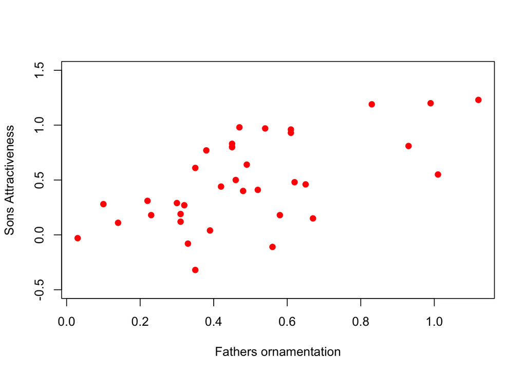

```r
# Make a scatterplot of father's ornamentation vs. son's attractiveness to see if father and son attractivenss correlates
plot(guppies$father.ornament, guppies$son.attract, # assigning values to xlab and ylab
     xlab = 'Fathers ornamentation', ylab = 'Sons Attractiveness', # giving xlab and ylab titles
     col = 'red', # giving the plot color
     pch = 19, # changing the shape of points
     ylim = c(-0.5, 1.5)) # assigning coordinate values
```

Desert bird dataset

```r
# empirical = bird dataset

# read in bird data
birds <- read.csv("~/Desktop/Classes/EEMB 146 S20/Week 3/Lab 3/Lab 3 Data-20200413/desert_birds.csv")

# create a cumulative density function (CDF) plot of species abundance distribtion of desert birds

# take a random normal sample that is the length of the count column in birds dataframe and has the same mean and standard deviation (sd)

# generate simulated data using our bird dataset
norm_data <- rnorm(length(birds$Count), mean = mean(birds$Count), sd = sd(birds$Count))

# make an empirical CDF of birds
emp_cdf <- ecdf(birds$Count)

# make an CDF of the normal sample
norm_cdf <- ecdf(norm_data)

# plot the bird CDF
plot(emp_cdf, # specifying this dataset
     col = 'red', # data from that dataset will be in red
     main = 'CDF of bird counts compared to normal distribution',  # giving a main title
     xlab = 'Count', ylab = 'Cumulative relative frequency') + # giving xlab and ylab titles
     lines(norm_cdf, col = 'blue') # calling in norm_cdf dataset and making it blue
```

```
## integer(0)
```

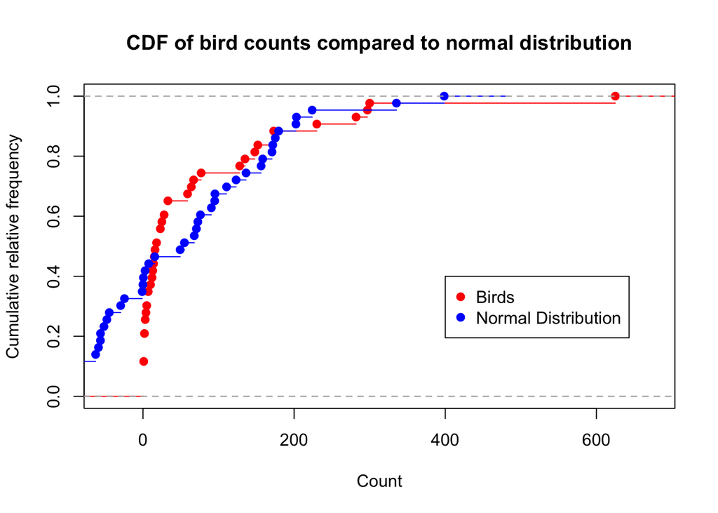

```r
legend(400, 0.4, c('Birds', 'Normal Distribution'), col = c('red', 'blue'), pch = c(19,19)) # making a legend
```

```r
# legend(location, names, color of names, shape of points)
```

Making a Line Plot

Lynx dataset

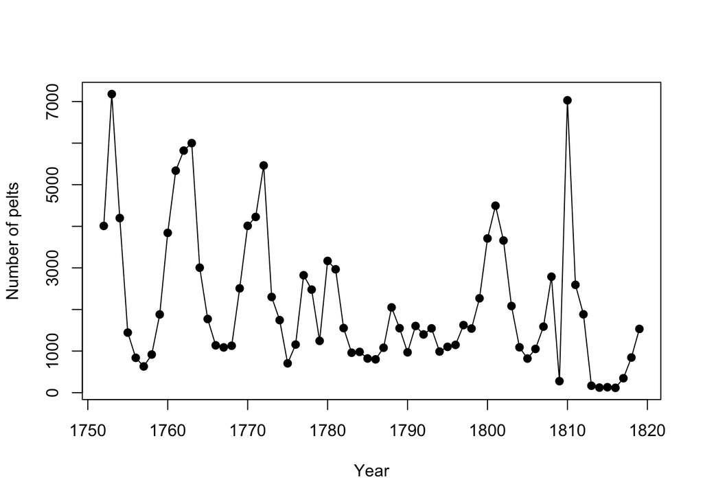

```
## integer(0)
```

```r
# read in dataset
lynx <- read.csv("~/Desktop/Classes/EEMB 146 S20/Week 3/Lab 3/Lab 3 Data-20200413/lynx_data.csv")

# lets plot to see the number of pelts collected per year over time

# Method 1
plot(lynx$date, # assign value to x-axis
     lynx$no.pelts, # assign value to y-axis
     pch = 19, # size of points
     xlab = 'Year', # give x-axis a title
     ylab = 'Number of pelts') + # give y-axis a title
  lines(lynx$date, lynx$no.pelts) # assigning values to lines
```

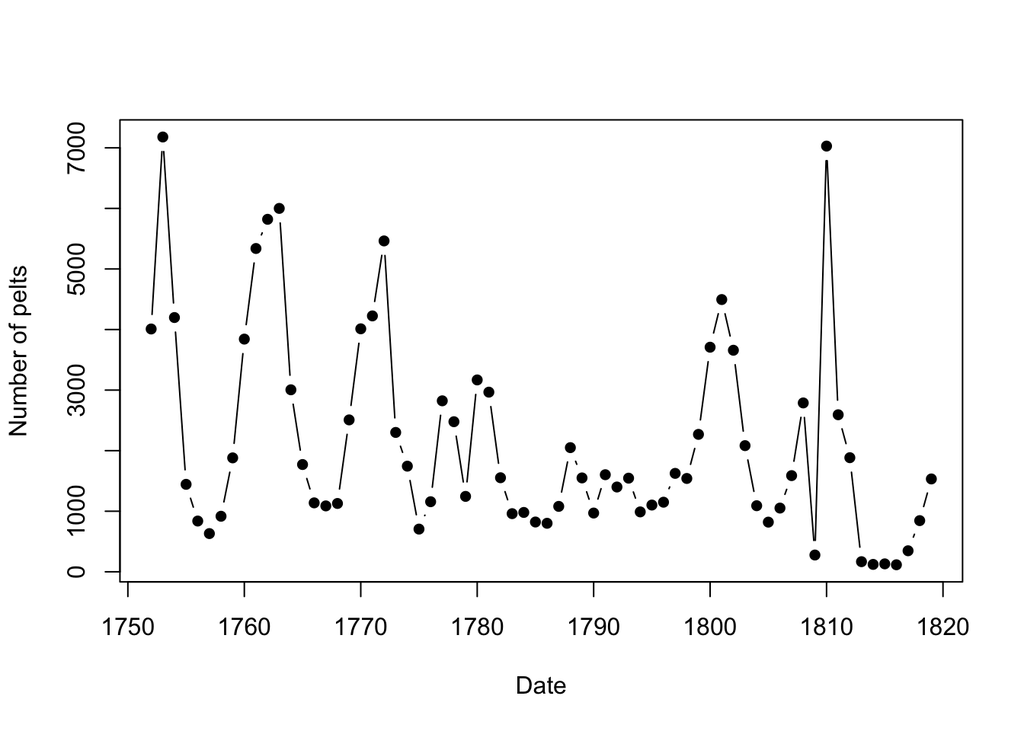

```r
# Method 2
plot(no.pelts ~ date, # plotting date (independent variable, X) by number of pelts (dependent variable, Y)
     data = lynx, # calling data from lynx dataset
     pch = 16, # size of points
     type = 'b', # type of plot is both (points + lines)
     xlab = 'Date', # give x-axis a title
     ylab = 'Number of pelts') # give y-axis a title
```

```r
# use `?plot` if you have questions!
```

Plant dataset

```r
# Are plant communities along the habitat edge different than plant communities that are not on the edge?

# read in dataset
plant <- read.csv("~/Desktop/Classes/EEMB 146 S20/Week 3/Lab 3/Lab 3 Data-20200413/plant_data.csv")

# view and explore data
head(plant)
```

```
##   tran_number sp_richness percent_cover dist_from_edge_m dist_from_tree_m
## 1           0           4            95             0.0m               20
## 2           0           2            95             3.0m               17
## 3           0           3            98             6.0m               15
## 4           1           4            90             0.0m                9
## 5           1           5            75             3.0m                7
## 6           1           5            75             3.0m                7
##   day_of_week num_flowers num_dand_flowers num_leaves_in_rosette
## 1     Tuesday         140                0                    NA
## 2     Tuesday           0                0                    NA
## 3     Tuesday           0                0                    NA
## 4     Tuesday           0                0                    NA
## 5     Tuesday           8                7                    11
## 6     Tuesday           8                7                     5
##   dand_rosette_diam_cm
## 1                   NA
## 2                   NA
## 3                   NA
## 4                   NA
## 5                  9.0
## 6                  8.8
```

```r
# look at vairables
names(plant)
```

```
##  [1] "tran_number"           "sp_richness"           "percent_cover"
##  [4] "dist_from_edge_m"      "dist_from_tree_m"      "day_of_week"
##  [7] "num_flowers"           "num_dand_flowers"      "num_leaves_in_rosette"
## [10] "dand_rosette_diam_cm"
```

```r
# run basic summary statistics
summary(plant)
```

```
##   tran_number     sp_richness     percent_cover    dist_from_edge_m
##  Min.   : 0.00   Min.   : 1.000   Min.   :  0.50   0.0m: 91
##  1st Qu.: 9.00   1st Qu.: 4.000   1st Qu.: 62.50   3.0m:101
##  Median :14.00   Median : 5.000   Median : 75.00   6.0m: 67
##  Mean   :14.58   Mean   : 5.039   Mean   : 73.87
##  3rd Qu.:20.50   3rd Qu.: 6.000   3rd Qu.: 90.00
##  Max.   :30.00   Max.   :10.000   Max.   :100.00
##
##  dist_from_tree_m     day_of_week  num_flowers     num_dand_flowers
##  Min.   : 1.00    Monday    :73   Min.   :  0.00   Min.   : 0.000
##  1st Qu.: 6.00    Monday    : 3   1st Qu.:  2.00   1st Qu.: 1.000
##  Median : 8.00    Thursday  :71   Median :  6.00   Median : 3.000
##  Mean   :10.72    Tuesday   :71   Mean   : 11.78   Mean   : 6.652
##  3rd Qu.:13.00    Tuesday   : 1   3rd Qu.: 13.00   3rd Qu.: 8.000
##  Max.   :40.00    Wednesday :33   Max.   :145.00   Max.   :36.000
##                   Wednesday : 7                    NA's   :3
##  num_leaves_in_rosette dand_rosette_diam_cm
##  Min.   : 0.00         Min.   : 0.000
##  1st Qu.: 6.00         1st Qu.: 7.000
##  Median : 8.00         Median : 9.000
##  Mean   :10.08         Mean   : 8.682
##  3rd Qu.:12.00         3rd Qu.:11.000
##  Max.   :39.00         Max.   :18.000
##  NA's   :42            NA's   :42
```

```r
# look at data structure, what types of variables are you dealing with
str(plant)
```

```
## 'data.frame':    259 obs. of  10 variables:
##  $ tran_number          : int  0 0 0 1 1 1 1 1 1 1 ...
##  $ sp_richness          : num  4 2 3 4 5 5 5 5 5 5 ...
##  $ percent_cover        : num  95 95 98 90 75 75 75 75 75 75 ...
##  $ dist_from_edge_m     : Factor w/ 3 levels "0.0m","3.0m",..: 1 2 3 1 2 2 2 2 2 2 ...
##  $ dist_from_tree_m     : num  20 17 15 9 7 7 7 7 7 7 ...
##  $ day_of_week          : Factor w/ 7 levels "Monday","Monday ",..: 4 4 4 4 4 4 4 4 4 4 ...
##  $ num_flowers          : num  140 0 0 0 8 8 8 8 8 8 ...
##  $ num_dand_flowers     : num  0 0 0 0 7 7 7 7 7 7 ...
##  $ num_leaves_in_rosette: num  NA NA NA NA 11 5 6 15 16 8 ...
##  $ dand_rosette_diam_cm : num  NA NA NA NA 9 8.8 9.3 11.9 12 9.2 ...
```

```r
# look at dimensions of data
dim(plant) # rows, columns
```

```
## [1] 259  10
```

Write all answers in Rmarkdown file and include the code necessary to reproduce your results exactly. All answers should be in complete sentences

# Exercise 1: distributions

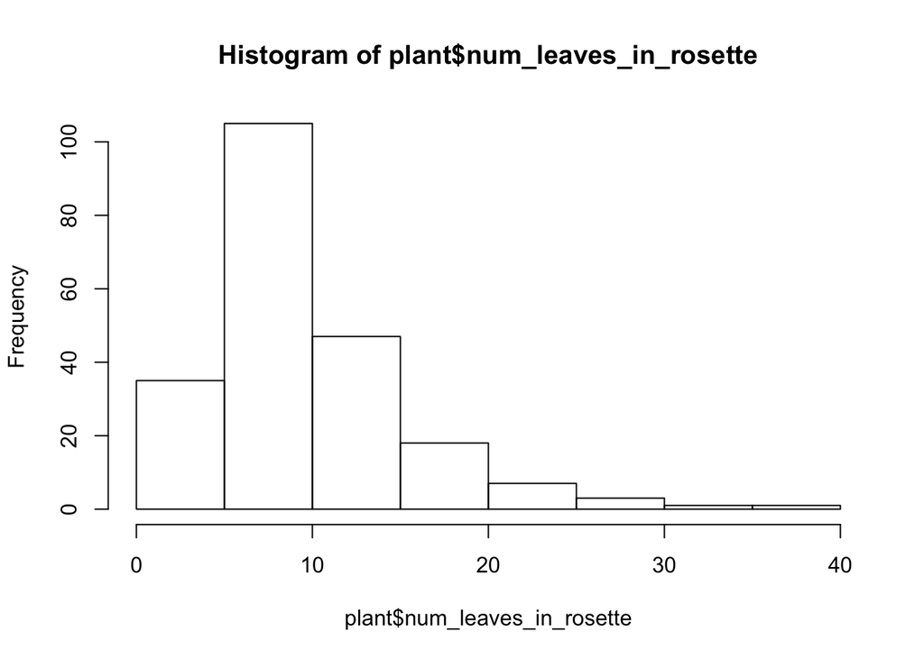

```r
# ?hist

# make histogram of no. of leaves in rosette
hist(plant$num_leaves_in_rosette)
```

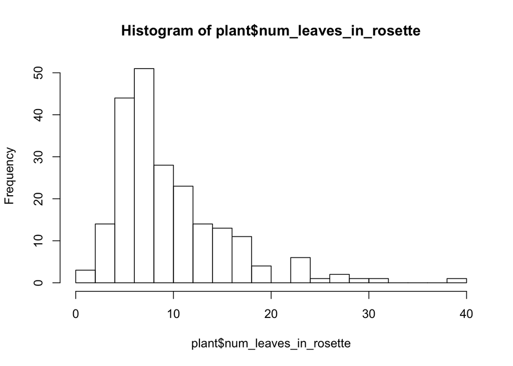

```r
# changing number of breaks will give you more/fewer bins ~ play around with this
hist(plant$num_leaves_in_rosette, breaks = 20)
```

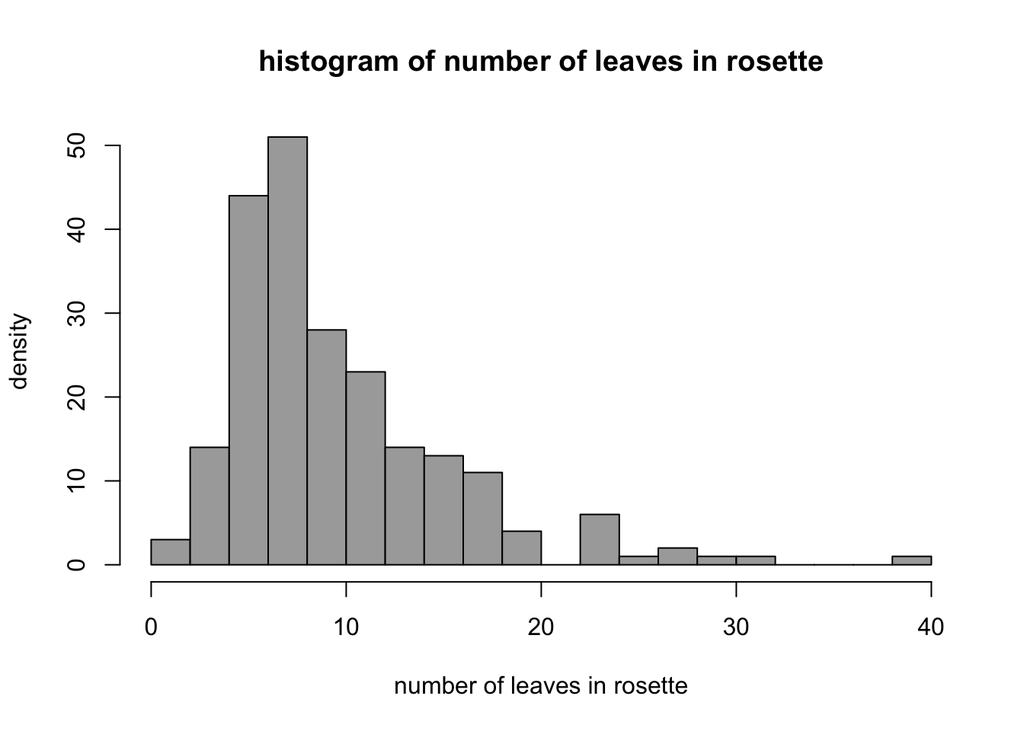

```r
# give your histogram pizazz
hist(plant$num_leaves_in_rosette, # looking at 'leaves_in_rosette' column in plant dataset
     breaks = 20, # bining your data in groups of 20
     col = 'darkgrey', # assinging fill in color of histogram
     xlab = 'number of leaves in rosette', # giving x-axis title
     ylab = 'density', # giving y-axis title
     main = 'histogram of number of leaves in rosette') # giving main title
```

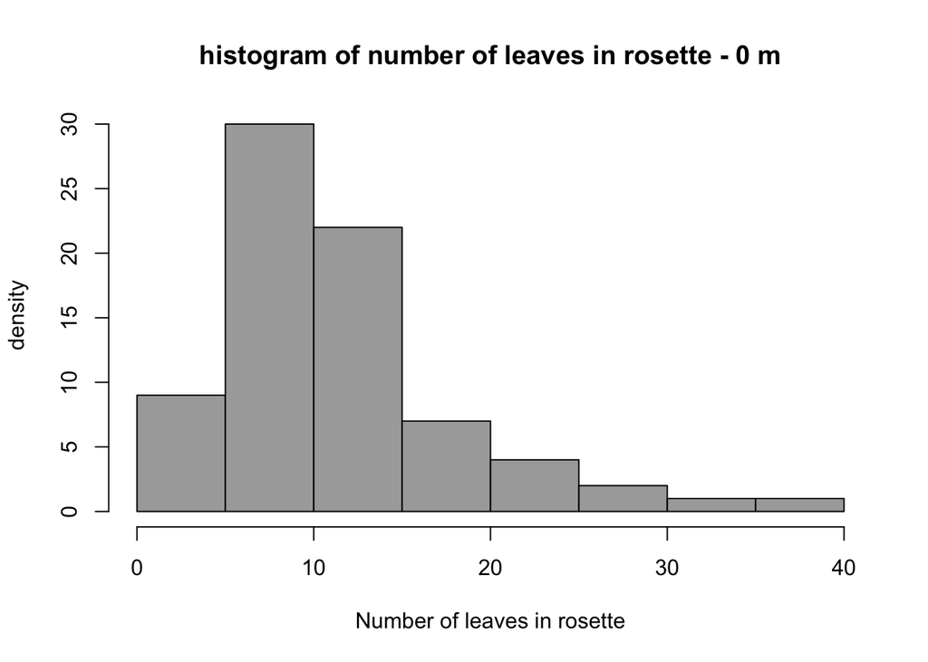

```r
# let's compare number of dandelion leaves between 0 m, 3 m, 6 m from habitat edge

# leaves 0 m from habitat edge
hist(plant$num_leaves_in_rosette[plant$dist_from_edge_m == '0.0m'], # selecting data that equals 0.0m (has to be exact)
     col = 'darkgrey', # fill in color of histogram
     xlab = 'Number of leaves in rosette', # giving x-axis title
     ylab = ' density',  # giving y-axis title
     main = 'histogram of number of leaves in rosette - 0 m', # giving main title
     xlim = c(0,40)) # setting xlab coordinates
```

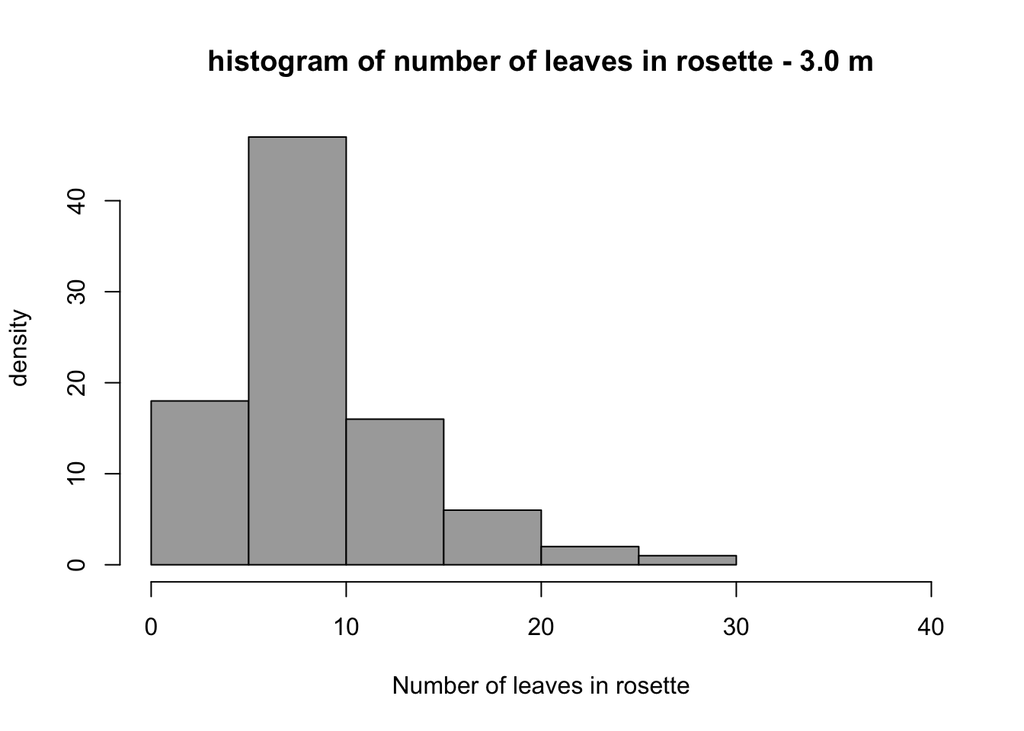

```r
# leaves 3 m from habitat edge
hist(plant$num_leaves_in_rosette[plant$dist_from_edge_m == '3.0m'], # selecting data that equals 0.0m (has to be exact)
     col = 'darkgrey', # fill in color of histogram
     xlab = 'Number of leaves in rosette', # giving x-axis title
     ylab = ' density',  # giving y-axis title
     main = 'histogram of number of leaves in rosette - 3.0 m', # giving main title
     xlim = c(0,40)) # setting xlab coordinates
```

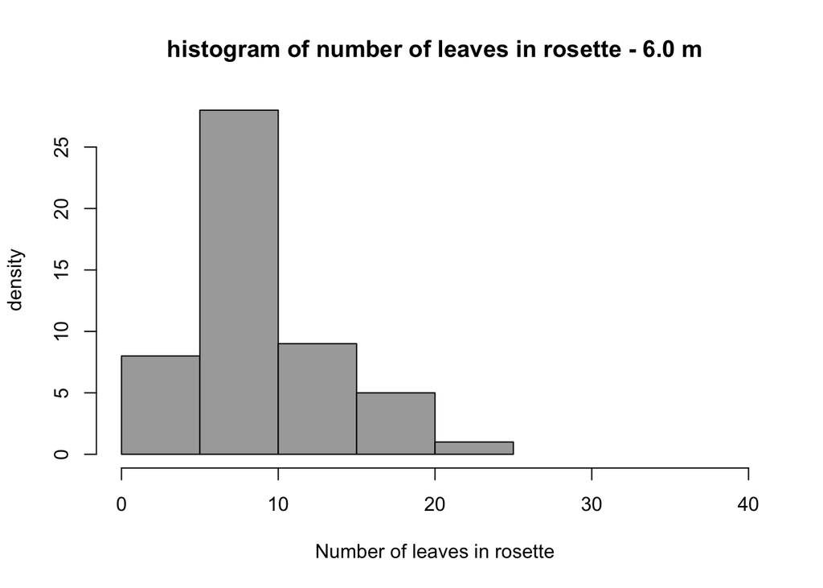

```r
# leaves 6 m from habitat edge
hist(plant$num_leaves_in_rosette[plant$dist_from_edge_m == '6.0m'], # selecting data that equals 0.0m (has to be exact)
     col = 'darkgrey', # fill in color of histogram
     xlab = 'Number of leaves in rosette', # giving x-axis title
     ylab = ' density',  # giving y-axis title
     main = 'histogram of number of leaves in rosette - 6.0 m', # giving main title
     xlim = c(0,40)) # setting xlab coordinates
```

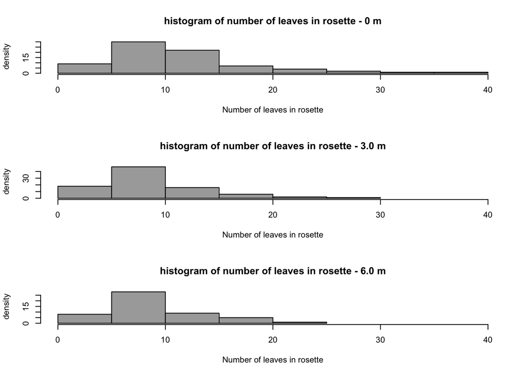

```r
# let's combine all 3 histograms in one plot
par(mfrow = c(3,1)) # sets up your plot (3 x 1)
# leaves 0 m from habitat edge
hist(plant$num_leaves_in_rosette[plant$dist_from_edge_m == '0.0m'], # selecting data that equals 0.0m (has to be exact)
     col = 'darkgrey', # fill in color of histogram
     xlab = 'Number of leaves in rosette', # giving x-axis title
     ylab = ' density',  # giving y-axis title
     main = 'histogram of number of leaves in rosette - 0 m', # giving main title
     xlim = c(0,40)) # setting xlab coordinates

# leaves 3 m from habitat edge
hist(plant$num_leaves_in_rosette[plant$dist_from_edge_m == '3.0m'], # selecting data that equals 0.0m (has to be exact)
     col = 'darkgrey', # fill in color of histogram
     xlab = 'Number of leaves in rosette', # giving x-axis title
     ylab = ' density',  # giving y-axis title
     main = 'histogram of number of leaves in rosette - 3.0 m', # giving main title
     xlim = c(0,40)) # setting xlab coordinates

# leaves 6 m from habitat edge
hist(plant$num_leaves_in_rosette[plant$dist_from_edge_m == '6.0m'], # selecting data that equals 0.0m (has to be exact)
     col = 'darkgrey', # fill in color of histogram
     xlab = 'Number of leaves in rosette', # giving x-axis title
     ylab = ' density',  # giving y-axis title
     main = 'histogram of number of leaves in rosette - 6.0 m', # giving main title
     xlim = c(0,40)) # setting xlab coordinates
```

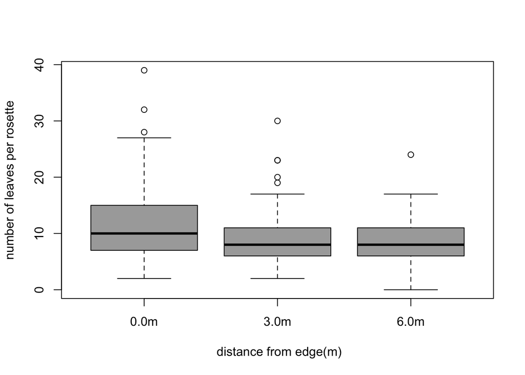

```r
## SWITCH THIS BACK TO 1 PLOT AT A TIME ##

par(mfrow = c(1,1))


# Let's create a boxplot.

# How does distance from edge of habitat (explanatory variable) affect number of leaves per rosette (response variable)?

boxplot(num_leaves_in_rosette~dist_from_edge_m, # plotting independent variable, X by dependent variable, Y
        data = plant, # calling from plant dataset
        xlab = ' distance from edge(m)',  # title
        ylab = 'number of leaves per rosette', # title
        col = 'darkgrey') # fill in color of boxplot
```

# Question 1

Follow exercise above but use the data for ‘dand_rosette_diam_cm’

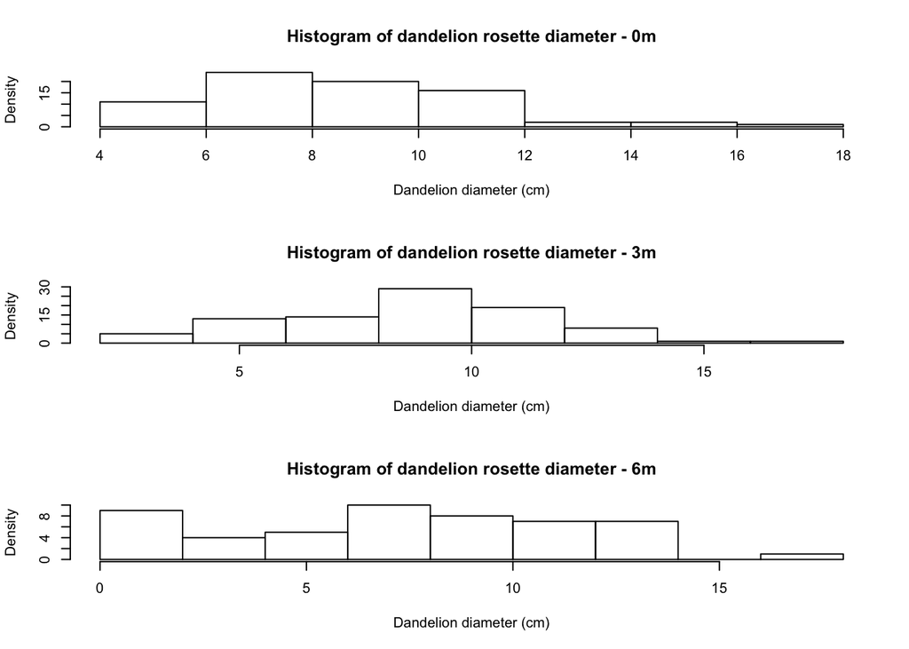

```r
## a) Describe the shape of the dandelion rosette diameter distribution for different distances from the edge. are they symmetrical or skewed?

# I am recalling dataset
plant <- read.csv("~/Desktop/Classes/EEMB 146 S20/Week 3/Lab 3/Lab 3 Data-20200413/plant_data.csv")

# Make a histogram to look at data shape
par(mfrow=c(3,1))
hist(plant$dand_rosette_diam_cm[plant$dist_from_edge_m == "0.0m"], xlab="Dandelion diameter (cm)", ylab="Density", main = "Histogram of dandelion rosette diameter - 0m")
hist(plant$dand_rosette_diam_cm[plant$dist_from_edge_m == "3.0m"], xlab="Dandelion diameter (cm)", ylab="Density", main = "Histogram of dandelion rosette diameter - 3m")
hist(plant$dand_rosette_diam_cm[plant$dist_from_edge_m == "6.0m"], xlab="Dandelion diameter (cm)", ylab="Density", main = "Histogram of dandelion rosette diameter - 6m")
```

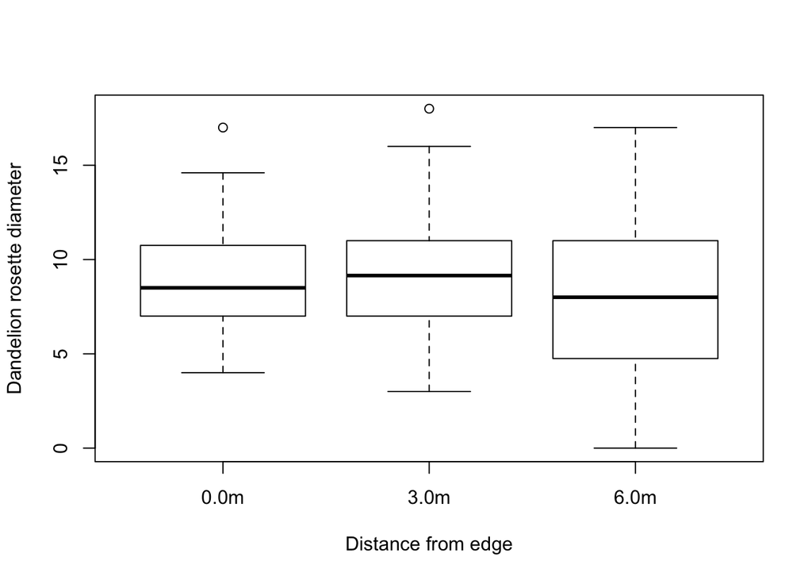

```r
## ANSWER: All the data looks slightly skewed, with tails pointing in the right. However, 0 m and 3 m look the most normal

## b) Based on the boxplot, how do the medians and dispersion (aka spread of data) compare across different distances from the edge? Would you feel confidence concluding that the distance from the edge has a significant effect on dandelion rosette diameter?

# return plot display to normal
par(mfrow=c(1,1))

# Make a boxplot of dandelion rosette diameter
boxplot(dand_rosette_diam_cm ~ dist_from_edge_m,
        data = plant, # state which dataset
        xlab="Distance from edge", #title
            ylab="Dandelion rosette diameter") # title
```

```r
## ANSWER: The median rosette diameters are very similar at different distances from the edge.  However, the dispersion or spread of the data increases as the distance from the edge increases. Based on this, I would not feel confident concluding that there is a significant effect of edge on median rosette diameter, but I would feel confident concluding that there is a significant effect of edge on the variance in rosette diameter.
```

## Exercise 2: Transformations [don’t include in data file]

Transformations in data analysis to make our data look more normal

```r
# create a new variable, natural log + 1 (Log transformation)
log_num_flowers <- log(plant$num_flowers + 1) # create new column
head(log_num_flowers) # what do the transformed numbers look like now
```

```
## [1] 4.948760 0.000000 0.000000 0.000000 2.197225 2.197225
```

```r
# if you want to create a new variable AND add it to your dataframe
plant$log_num_flowers <- log(plant$num_flowers + 1)
str(plant) # double check it's there
```

```
## 'data.frame':    259 obs. of  11 variables:
##  $ tran_number          : int  0 0 0 1 1 1 1 1 1 1 ...
##  $ sp_richness          : num  4 2 3 4 5 5 5 5 5 5 ...
##  $ percent_cover        : num  95 95 98 90 75 75 75 75 75 75 ...
##  $ dist_from_edge_m     : Factor w/ 3 levels "0.0m","3.0m",..: 1 2 3 1 2 2 2 2 2 2 ...
##  $ dist_from_tree_m     : num  20 17 15 9 7 7 7 7 7 7 ...
##  $ day_of_week          : Factor w/ 7 levels "Monday","Monday ",..: 4 4 4 4 4 4 4 4 4 4 ...
##  $ num_flowers          : num  140 0 0 0 8 8 8 8 8 8 ...
##  $ num_dand_flowers     : num  0 0 0 0 7 7 7 7 7 7 ...
##  $ num_leaves_in_rosette: num  NA NA NA NA 11 5 6 15 16 8 ...
##  $ dand_rosette_diam_cm : num  NA NA NA NA 9 8.8 9.3 11.9 12 9.2 ...
##  $ log_num_flowers      : num  4.95 0 0 0 2.2 ...
```

```r
## METHOD 2, use cbind() command
new_plant <- cbind(plant, log_num_flowers) # make new dataset with additional column
str(new_plant)
```

```
## 'data.frame':    259 obs. of  12 variables:
##  $ tran_number          : int  0 0 0 1 1 1 1 1 1 1 ...
##  $ sp_richness          : num  4 2 3 4 5 5 5 5 5 5 ...
##  $ percent_cover        : num  95 95 98 90 75 75 75 75 75 75 ...
##  $ dist_from_edge_m     : Factor w/ 3 levels "0.0m","3.0m",..: 1 2 3 1 2 2 2 2 2 2 ...
##  $ dist_from_tree_m     : num  20 17 15 9 7 7 7 7 7 7 ...
##  $ day_of_week          : Factor w/ 7 levels "Monday","Monday ",..: 4 4 4 4 4 4 4 4 4 4 ...
##  $ num_flowers          : num  140 0 0 0 8 8 8 8 8 8 ...
##  $ num_dand_flowers     : num  0 0 0 0 7 7 7 7 7 7 ...
##  $ num_leaves_in_rosette: num  NA NA NA NA 11 5 6 15 16 8 ...
##  $ dand_rosette_diam_cm : num  NA NA NA NA 9 8.8 9.3 11.9 12 9.2 ...
##  $ log_num_flowers      : num  4.95 0 0 0 2.2 ...
##  $ log_num_flowers      : num  4.95 0 0 0 2.2 ...
```

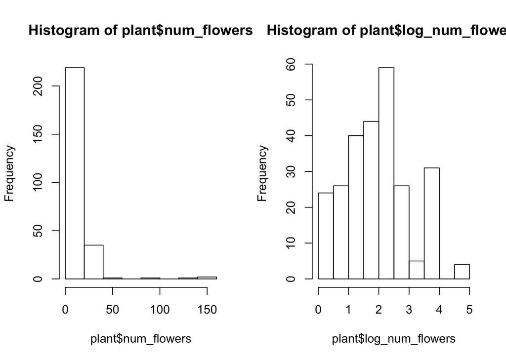

```r
par(mfrow = c(1,2)) # compare side to side
# hist of non-transformed data
hist(plant$num_flowers)
# hist of transformed data
hist(plant$log_num_flowers)
```

```r
# return back to normal plot settings
par(mfrow = c(1,1))


# to square num flowers
plant$num_flowers_sq <- plant$num_flowers^2
str(plant)
```

```
## 'data.frame':    259 obs. of  12 variables:
##  $ tran_number          : int  0 0 0 1 1 1 1 1 1 1 ...
##  $ sp_richness          : num  4 2 3 4 5 5 5 5 5 5 ...
##  $ percent_cover        : num  95 95 98 90 75 75 75 75 75 75 ...
##  $ dist_from_edge_m     : Factor w/ 3 levels "0.0m","3.0m",..: 1 2 3 1 2 2 2 2 2 2 ...
##  $ dist_from_tree_m     : num  20 17 15 9 7 7 7 7 7 7 ...
##  $ day_of_week          : Factor w/ 7 levels "Monday","Monday ",..: 4 4 4 4 4 4 4 4 4 4 ...
##  $ num_flowers          : num  140 0 0 0 8 8 8 8 8 8 ...
##  $ num_dand_flowers     : num  0 0 0 0 7 7 7 7 7 7 ...
##  $ num_leaves_in_rosette: num  NA NA NA NA 11 5 6 15 16 8 ...
##  $ dand_rosette_diam_cm : num  NA NA NA NA 9 8.8 9.3 11.9 12 9.2 ...
##  $ log_num_flowers      : num  4.95 0 0 0 2.2 ...
##  $ num_flowers_sq       : num  19600 0 0 0 64 64 64 64 64 64 ...
```